# Project_All_life_Credit_Card_Clustering

## AllLife Credit Card Customer Segmentation

### Background and Context

AllLife Bank wants to focus on its credit card customer base in the next financial year. They have been advised by their marketing research team, that the penetration in the market can be improved. Based on this input, the Marketing team proposes to run personalised campaigns to target new customers as well as upsell to existing customers. Another insight from the market research was that the customers perceive the support services of the back poorly. Based on this, the Operations team wants to upgrade the service delivery model, to ensure that customers queries are resolved faster. Head of Marketing and Head of Delivery both decide to reach out to the Data Science team for help.

### Objective

To identify different segments in the existing customer based on their spending patterns as well as past interaction with the bank.

### Key Questions:

1. How many different segments of customers are there?
2. How are these segments different from each other?
3. What are your recommendations to the bank on how to better market to and service these customers?

### Data Description:

Data is of various customers of a bank with their credit limit, the total number of credit cards the customer has, and different channels through which customer has contacted the bank for any queries, different channels include visiting the bank, online and through a call centre.

```python
### Import libraries

import warnings

warnings.filterwarnings("ignore")

import numpy as np
import pandas as pd
import seaborn as sns
sns.set(color_codes=True)
import matplotlib.pyplot as plt
%matplotlib inline

from sklearn.preprocessing import StandardScaler
from scipy.spatial.distance import cdist
from scipy.spatial.distance import pdist
from sklearn.cluster import KMeans
from sklearn.metrics import silhouette_score
from yellowbrick.cluster import KElbowVisualizer, SilhouetteVisualizer
import scipy.stats as st



from scipy.cluster.hierarchy import dendrogram, linkage,cophenet
from sklearn.cluster import AgglomerativeClustering
```

### Read in data and review samples

```python
CC_df=pd.read_excel('Credit Card Customer Data.xlsx') #read in data
```

### Review first 5 and last 5 records

```python
CC_df.head(5) # first five records
```

|  | Sl_No | Customer Key | Avg_Credit_Limit | Total_Credit_Cards | Total_visits_bank | Total_visits_online | Total_calls_made |
| --- | --- | --- | --- | --- | --- | --- | --- |
| 0 | 1 | 87073 | 100000 | 2 | 1 | 1 | 0 |
| 1 | 2 | 38414 | 50000 | 3 | 0 | 10 | 9 |
| 2 | 3 | 17341 | 50000 | 7 | 1 | 3 | 4 |
| 3 | 4 | 40496 | 30000 | 5 | 1 | 1 | 4 |
| 4 | 5 | 47437 | 100000 | 6 | 0 | 12 | 3 |

```python
CC_df.tail(5) # last five records
```

|  | Sl_No | Customer Key | Avg_Credit_Limit | Total_Credit_Cards | Total_visits_bank | Total_visits_online | Total_calls_made |
| --- | --- | --- | --- | --- | --- | --- | --- |
| 655 | 656 | 51108 | 99000 | 10 | 1 | 10 | 0 |
| 656 | 657 | 60732 | 84000 | 10 | 1 | 13 | 2 |
| 657 | 658 | 53834 | 145000 | 8 | 1 | 9 | 1 |
| 658 | 659 | 80655 | 172000 | 10 | 1 | 15 | 0 |
| 659 | 660 | 80150 | 167000 | 9 | 0 | 12 | 2 |

**Insights:**

- Data appears well populated
- it appears the first two columns are a type of of identifers
  - SI_No
  - Customer Key
- there looks like 5 informational fields:
  - Avg_Credit_Limit
  - Total_Credit_Cards
  - Total_visits_bank
  - Total_visits_online
  - Total_calls_made
- There isn't a good data dictionary, so will have to use implied meaning from variable names

**Check Shape of Data, Check data types and number of non-null values for each column.**

```python
CC_df.shape
```

```
(660, 7)
```

**Insights:**

- There are 660 observations with 7 variables

```python
CC_df.info()
```

```
<class 'pandas.core.frame.DataFrame'>
RangeIndex: 660 entries, 0 to 659
Data columns (total 7 columns):
 #   Column               Non-Null Count  Dtype
---  ------               --------------  -----
 0   Sl_No                660 non-null    int64
 1   Customer Key         660 non-null    int64
 2   Avg_Credit_Limit     660 non-null    int64
 3   Total_Credit_Cards   660 non-null    int64
 4   Total_visits_bank    660 non-null    int64
 5   Total_visits_online  660 non-null    int64
 6   Total_calls_made     660 non-null    int64
dtypes: int64(7)
memory usage: 36.2 KB
```

**Insights:**

- There appears to be no missing values
- all the variables are int64

```python
CC_df.isna().sum()
```

```
Sl_No                  0
Customer Key           0
Avg_Credit_Limit       0
Total_Credit_Cards     0
Total_visits_bank      0
Total_visits_online    0
Total_calls_made       0
dtype: int64
```

**Insights:**

- There are no missing values

### Check unique values

```python
CC_df.nunique() #need to change order of this. Want this before the dropped sections to improve flow
```

```
Sl_No                  660
Customer Key           655
Avg_Credit_Limit       110
Total_Credit_Cards      10
Total_visits_bank        6
Total_visits_online     16
Total_calls_made        11
dtype: int64
```

**Insights:**

- Sl_no and Customer Key are identifiers. Going to drop these to variables
- There are 110 different average credit limits
- Total visits to bank is the least varied variable at 6 different unique numbers for visits

```python
# Drop Identifiers
CC_df.drop(columns=['Sl_No','Customer Key'], inplace=True)
```

### Summary of Data

```python
CC_df.describe()
```

|  | Avg_Credit_Limit | Total_Credit_Cards | Total_visits_bank | Total_visits_online | Total_calls_made |
| --- | --- | --- | --- | --- | --- |
| count | 660.000000 | 660.000000 | 660.000000 | 660.000000 | 660.000000 |
| mean | 34574.242424 | 4.706061 | 2.403030 | 2.606061 | 3.583333 |
| std | 37625.487804 | 2.167835 | 1.631813 | 2.935724 | 2.865317 |
| min | 3000.000000 | 1.000000 | 0.000000 | 0.000000 | 0.000000 |
| 25% | 10000.000000 | 3.000000 | 1.000000 | 1.000000 | 1.000000 |
| 50% | 18000.000000 | 5.000000 | 2.000000 | 2.000000 | 3.000000 |
| 75% | 48000.000000 | 6.000000 | 4.000000 | 4.000000 | 5.000000 |
| max | 200000.000000 | 10.000000 | 5.000000 | 15.000000 | 10.000000 |

**Insights:**

- Avg_Credit_Limit is right skewed as the mean is 34.5k and Median is 18k
- An average customer had roughly 5 credit cards
- Between Total_visits_bank, Total_Visits_online and Total_calls_made, Total_visits_online has the biggest range with a range of 15 compared to 5(Total_visits_bank) and 10(Total_calls_made)
- Average of 3.6 total calls made by customers
- Average Total_Credit_Cards is 4.7
- Average Total_visits_Bank is 2.4
- Average Total_visits_online is 2.6

## Univariate analysis

### Create Histograms and Boxplots

```python
#Function to create Histogram and Boxplot
def histogram_boxplot(feature, figsize=(10,5), bins = None):
    """ Boxplot and histogram combined
    feature: 1-d feature array
    figsize: size of fig (default (9,8))
    bins: number of bins (default None / auto)
    """
    f2, (ax_box2, ax_hist2) = plt.subplots(nrows = 2,
                                           sharex = True,
                                           gridspec_kw = {"height_ratios": (.25, .75)},
                                           figsize = figsize
                                           )
    sns.boxplot(feature, ax=ax_box2, showmeans=True, color='violet')
    sns.distplot(feature, kde=F, ax=ax_hist2, bins=bins,palette="winter") if bins else sns.distplot(feature, kde=False, ax=ax_hist2)
    ax_hist2.axvline(np.mean(feature), color='green', linestyle='--')
    ax_hist2.axvline(np.median(feature), color='black', linestyle='-')
```

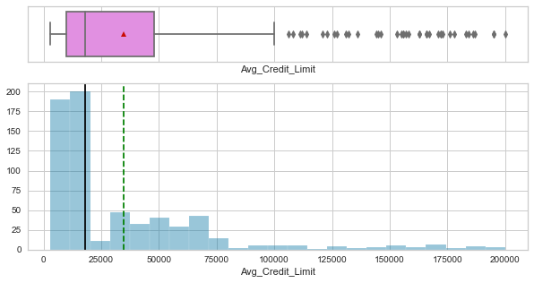

```python
histogram_boxplot(CC_df['Avg_Credit_Limit'])
```

**Insights:**

- There is a multimodal distribtuion
- There is a cluster below 25k then another cluster from 25k to about 80k
- There are several outliers, but all of them seem possible
- There is a right skew to the data

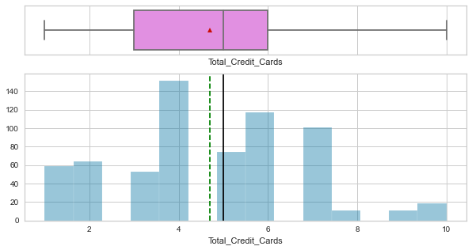

```python
histogram_boxplot(CC_df['Total_Credit_Cards'])
```

**Insights:**

- 4 is the most common amount of credit cards to have followed by 6 credit cards
- There are no outliers
- The data is slightly left skewed

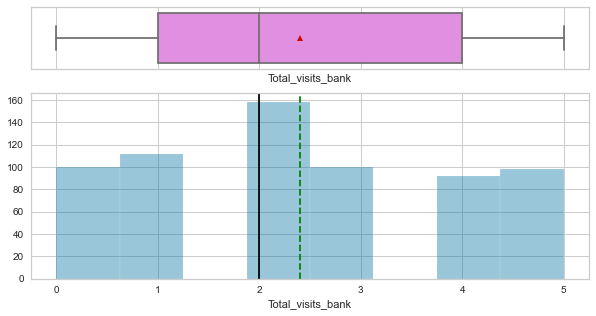

```python
histogram_boxplot(CC_df['Total_visits_bank'])
```

**Insights:**

- the data is almost uniformed going 0 to 5 bank visits
- 2 is the most common bank visit frequency

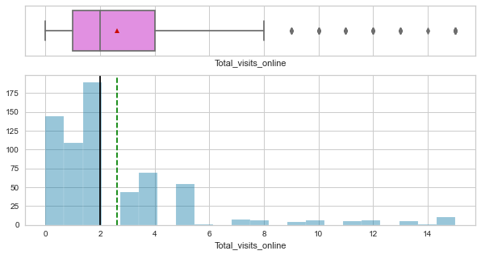

```python
histogram_boxplot(CC_df['Total_visits_online'])
```

**Insights:**

- The distribution is right skewed
- There are several outliers
- The range of online visits goes from 0 to 15

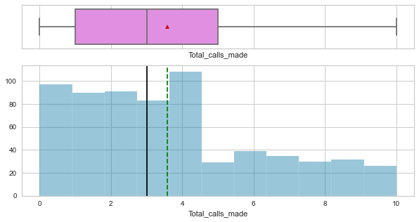

```python
histogram_boxplot(CC_df['Total_calls_made'])
```

**Insights:**

- The data is right skewed
- There are no outliers
- Looks like it could be multimodal
- The range goes from 0 to 10